# Major changes

Damiano

12/15/2021

### New dataset

#### New dataset only including events happening after the inclusion (*2015*)

```
# SELECT LINES WITH EVENTS > 2015
dgn_complete.2015 <- dgn_complete %>%
  select(evdate, inclusion, num_enq, RREC_COD_ANO, DGN_PAL) %>%
  filter(evdate > inclusion)

count(dgn_complete) # 18543
count(dgn_complete.2015) # 12678

# SORTING
dgn_one <- dgn_complete.2015 %>%
  group_by(num_enq, lubridate::date(evdate)) %>%
  arrange(evdate) %>%
  slice(1) %>%
  ungroup() %>%
  select(evdate, num_enq, DGN_PAL, DDIRT)

count(dgn_one) # 12678

# SQL COUNTING
library("sqldf")
dgn_oneclassifier <- sqldf("SELECT a.*, COUNT(*) count
       FROM dgn_one a, dgn_one b
       WHERE a.num_enq = b.num_enq AND b.ROWID <= a.ROWID
       GROUP BY a.ROWID"
)

# NEW DATABASE WITH ONLY THE FIRST EVENT PER PERSON
dgn_line = filter(dgn_oneclassifier, count == 1)
count(dgn_line) # 7979
```

#### Number of total events in ADPKD population

```
no-event    event
2255        305
```

#### Events according to transplantation status

When transplantation is taken into account, the number of total events drops to *255*. Fifty events occur after the transplantation and are not accounted as events anymore in the final analysis.

> Il y a la question de Clémence à laquelle je n’ai pas encore repondu dans cette analyse. En effet, les sujets ayant reçu une transplantation ne sont plus suivi dans le registre REIN et leur date de décès pourrait ne pas être disponible - alors qu’ils sont bien decedés.

```
            no event    event
event       0           255
no event    2255        50
```

Columns refer to the variable `apkd$event` which does not include the information about transplantation. Rows refer to the variable includinding the information about transplantation timing.

#### Type of event [^1]

```
G45  I60  I61  I62  I63  I64  I74 R471
 18    5   18   12   30    1  219    2

        G45         I60         I61         I62         I63
0.059016393 0.016393443 0.059016393 0.039344262 0.098360656
        I64         I74        R471
0.003278689 0.718032787 0.006557377
```

### *F*ollow-*UP*

#### Definition of the follow-up periods

##### Until the end of the follow up, set as December 31st 2019

```
FUP.19 = as.Date(adpkd$december, "%d/%m/%Y") - as.Date(adpkd$DDIRT, "%d/%m/%Y")
```

The variable `adpkd$december` replaces the previous *date des dernières nouvelles* variable.

##### Until death or event

```
# DEATH
FUP.D = as.Date(adpkd$DDC, "%d/%m/%Y") - as.Date(adpkd$DDIRT, "%d/%m/%Y")

# EVENT
FUP.E = as.Date(adpkd$evdate, "%d/%m/%Y") - as.Date(adpkd$DDIRT, "%d/%m/%Y")
```

##### Until transplatation

```
FUP.T = as.Date(adpkd$DGRF, "%d/%m/%Y") - as.Date(adpkd$DDIRT, "%d/%m/%Y")
```

#### Follow-up with `case_when`nested in `mutate`

```
adpkd <- adpkd %>%
  mutate(epilogus = case_when(
    # the patient is dead
    DEATH == "1" & e.b.d == "0" ~ FUP.D,
    # the patient is transplanted before the event
    t.b.e == "1" ~ FUP.T,
    # the patient is transplanted after the event
    t.b.e == "0" ~ FUP.E,
    # event
    EVENT == "1" & e.b.i != "1" ~ FUP.E,
    # no event
    EVENT == "0" ~ FUP.19
  ))
```

Acronyms *t.b.e* and *e.b.d* stand for *transplantation before the event* and *event before death* respectively. The latter is to be considered only as an additional check on the database coherence:

```
# TRANSPLANTATION HAPPENS BEFORE THE EVENT
0 (after transplantation)   1 (before transplantation)
45                          50

# EVENT HAPPENS BEFORE DEATH
0 (event after death)  1 (event before death)
20                     26
```

## Multivariate

### Multivariate by `coxph`

#### Results of the multivariate Cox proportional hazards model

```
             coef exp(coef)  se(coef)      z        p
URGn    -0.157209  0.854525  0.276306 -0.569  0.56938
KTTINIn -0.029415  0.971013  0.211573 -0.139  0.88943
EPOINIn -0.380860  0.683274  0.173490 -2.195  0.02814
IRCn    -1.053448  0.348733  0.454990 -2.315  0.02060
O2n      1.115171  3.050091  0.395874  2.817  0.00485
ICn      0.007248  1.007275  0.282037  0.026  0.97950
IDMn     0.167159  1.181942  0.340742  0.491  0.62373
ANEVn   -0.101613  0.903380  0.530427 -0.192  0.84808
AMIn    -0.017282  0.982866  0.324674 -0.053  0.95755
KCn     -0.395796  0.673144  0.422623 -0.937  0.34901
VHCn     0.716229  2.046701  1.024804  0.699  0.48462
bmi     -0.007109  0.992916  0.015758 -0.451  0.65188
tabac2   0.239885  1.271103  0.182133  1.317  0.18781
sex     -0.127581  0.880222  0.177280 -0.720  0.47173
age      0.012324  1.012400  0.006794  1.814  0.06969
TRANSP1 -1.075155  0.341245  0.217639 -4.940 7.81e-07
```

#### Proportional hazards assumption hypothesis testing

```
         chisq df      p
URGn     1.7642  1 0.1841
KTTINIn  0.0419  1 0.8379
EPOINIn  0.0459  1 0.8303
IRCn     0.0325  1 0.8569
O2n      0.5678  1 0.4511
ICn      2.3551  1 0.1249
IDMn     1.4723  1 0.2250
ANEVn    0.9764  1 0.3231
AMIn     1.3344  1 0.2480
KCn      0.0370  1 0.8475
VHCn     1.8136  1 0.1781
bmi      0.5879  1 0.4432
tabac2   1.1035  1 0.2935
sex      0.6310  1 0.4270
age      0.0500  1 0.8230
TRANSP   9.2069  1 0.0024
GLOBAL  24.3757 16 0.0816
```

#### Schoenfeld residuals for the multivariate `coxph`

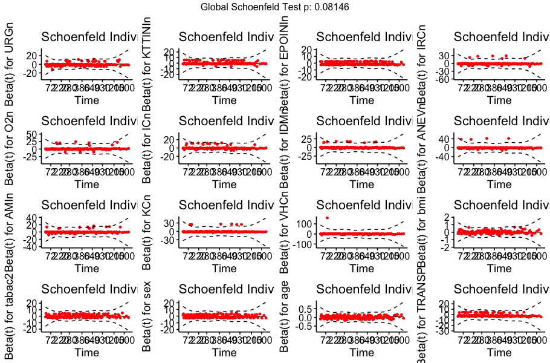

## Graphics

#### Kaplan-Meier estimator

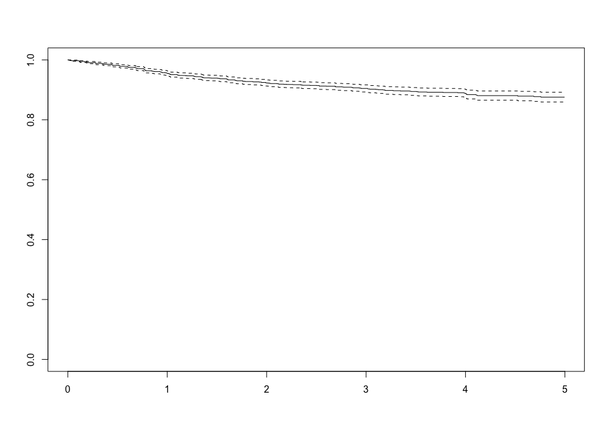

#### Cumulative incidence

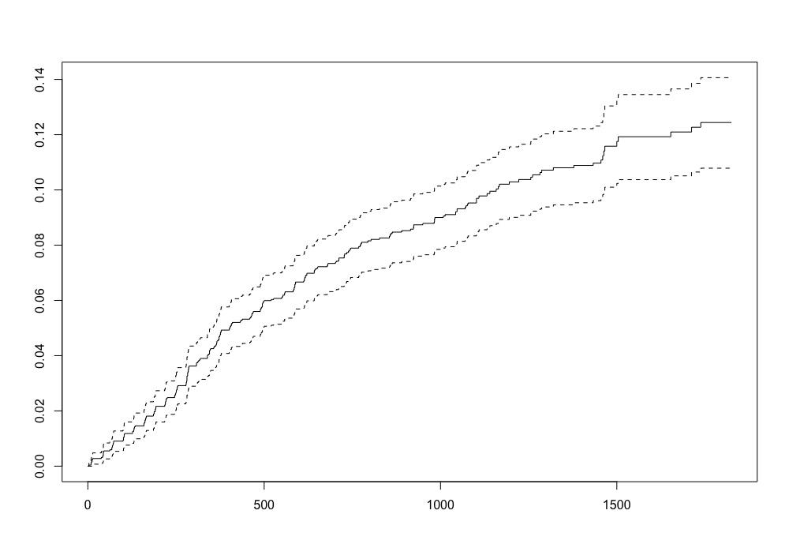

#### Adjusted survival by `cph`

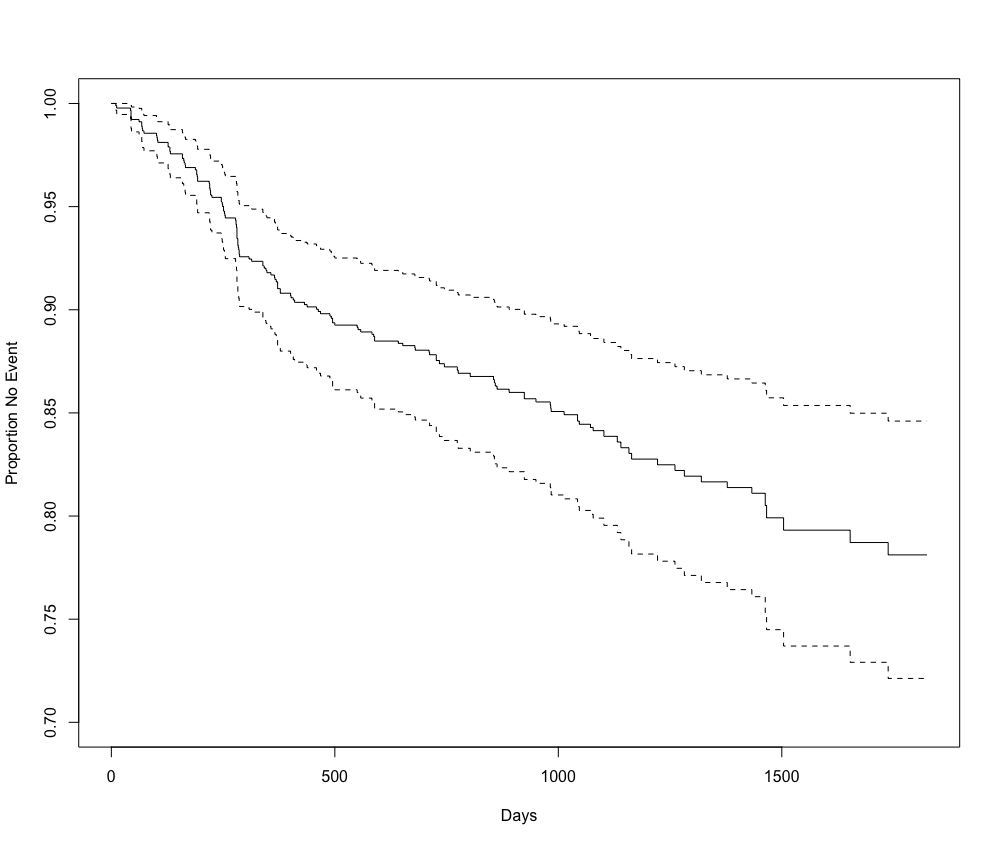

#### Incidence by dialysis method [^2]

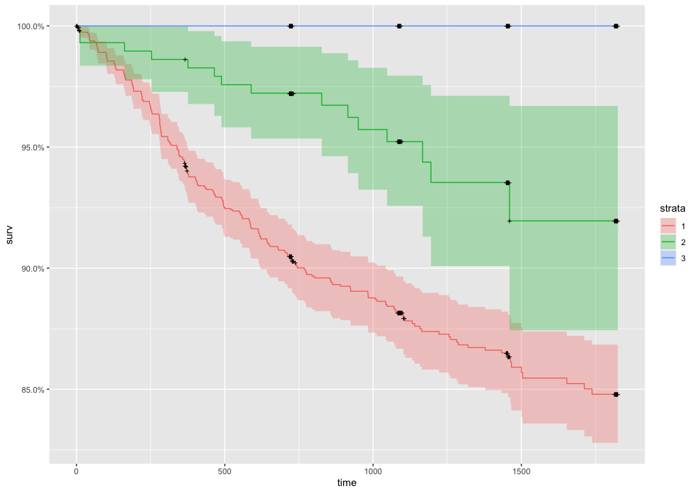

> Note: Nodes still represent a issue.

#### Incidence ADPKD *VS* OTHER NEPHOPATHY

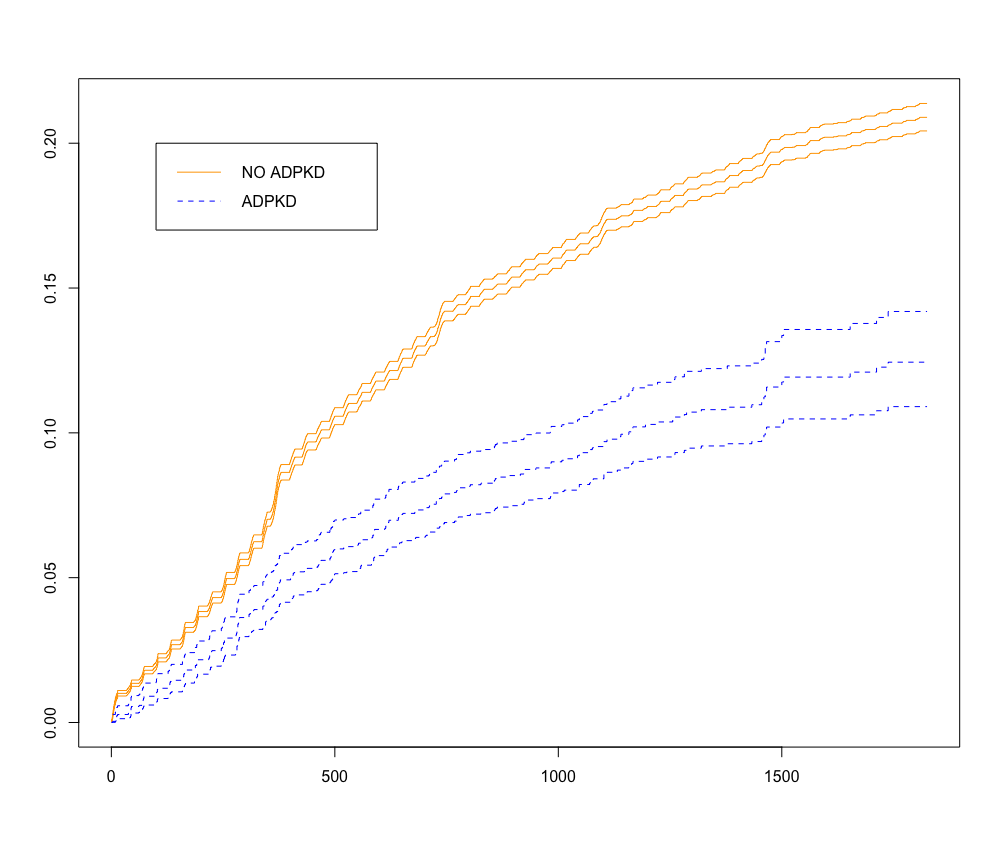

[^1]: | CIM-10 | Diagnostic |
    | --- | --- |
    | **G45** | accidents ischémiques cérébraux transitories et syndromes apparentés |
    | **I60** | hémorragie sous-arachnoïdienne |
    | **I61** | hémorragie intracérébrale |
    | **I62** | autres hémorragies intracrâniennes non traumatiques |
    | **I63** | infarctus cérébral |
    | **I64** | accident vasculaire cérévral non précisé (hémorragique ou infarctus) |
    | **I74** | embolie et thromose artérielle |
    | **R471** | dysarthrie et anarthrie |

[^2]: | Methode | Événement | Pas d’événement |
    | --- | --- | --- |
    | (1) Hémodialyse | 240 | 1691 |
    | (2) Dialyse péritonéale | 15 | 275 |
    | (3) Greffe | 0 | 339 |